# Regression Analysis 3

###Nonlinear Regression Essentials : Polynomial and Spline Regression Models

In some cases, the true relationship between the outcome and a predictor variable might not be linear.

There are different solutions extending the linear regression model for capturing these nonlinear effects, including:

- **Polynomial regression**  
  This is the simple approach to model non-linear relationships. It add polynomial terms or quadratic terms (square, cubes, etc) to a regression.
- **Spline regression**  
  Fits a smooth curve with a series of polynomial segments. The values delimiting the spline segments are called Knots.
- **Generalized additive models (GAM)**  
  Fits spline models with automated selection of knots.

you’ll learn how to compute non-linear regression models and how to compare the different models in order to choose the one that fits the best your data.

The **RMSE and the R2 metrics**, will be used to compare the different models.

Recall that,

- the **RMSE** represents the model prediction error, that is the average difference the observed outcome values and the predicted outcome values.
- The **R2** represents the squared correlation between the observed and predicted outcome values. The best model is the model with the lowest RMSE and the highest R2.

####1. Loading Required R packages

- `{tidyverse}` for easy data manipulation and visualization
- `{caret}` for easy machine learning workflow

```r
library(tidyverse)
library(caret)

theme_set(theme_classic())
```

####2. Preparing the data

We’ll use the `Boston{MASS}` data set for predicting the median house value (**mdev**), in Boston Suburbs, based on the predictor variable lstat (percentage of lower status of the population).

We’ll randomly **split** the data into **training set** (**80%** for building a predictive model) and **test set** (**20%** for evaluating the model). Make sure to set seed for **reproducibility**.

```r
library(MASS)

# Load the data
data("Boston")
```

```r
library(DT)
datatable(Boston)
```

|  | crim | zn | indus | chas | nox | rm | age | dis | rad | tax | ptratio | black | lstat | medv |
| --- | --- | --- | --- | --- | --- | --- | --- | --- | --- | --- | --- | --- | --- | --- |
| 1 | 0.00632 | 18 | 2.31 | 0 | 0.538 | 6.575 | 65.2 | 4.09 | 1 | 296 | 15.3 | 396.9 | 4.98 | 24 |
| 2 | 0.02731 | 0 | 7.07 | 0 | 0.469 | 6.421 | 78.9 | 4.9671 | 2 | 242 | 17.8 | 396.9 | 9.14 | 21.6 |
| 3 | 0.02729 | 0 | 7.07 | 0 | 0.469 | 7.185 | 61.1 | 4.9671 | 2 | 242 | 17.8 | 392.83 | 4.03 | 34.7 |
| 4 | 0.03237 | 0 | 2.18 | 0 | 0.458 | 6.998 | 45.8 | 6.0622 | 3 | 222 | 18.7 | 394.63 | 2.94 | 33.4 |
| 5 | 0.06905 | 0 | 2.18 | 0 | 0.458 | 7.147 | 54.2 | 6.0622 | 3 | 222 | 18.7 | 396.9 | 5.33 | 36.2 |
| 6 | 0.02985 | 0 | 2.18 | 0 | 0.458 | 6.43 | 58.7 | 6.0622 | 3 | 222 | 18.7 | 394.12 | 5.21 | 28.7 |
| 7 | 0.08829 | 12.5 | 7.87 | 0 | 0.524 | 6.012 | 66.6 | 5.5605 | 5 | 311 | 15.2 | 395.6 | 12.43 | 22.9 |
| 8 | 0.14455 | 12.5 | 7.87 | 0 | 0.524 | 6.172 | 96.1 | 5.9505 | 5 | 311 | 15.2 | 396.9 | 19.15 | 27.1 |
| 9 | 0.21124 | 12.5 | 7.87 | 0 | 0.524 | 5.631 | 100 | 6.0821 | 5 | 311 | 15.2 | 386.63 | 29.93 | 16.5 |
| 10 | 0.17004 | 12.5 | 7.87 | 0 | 0.524 | 6.004 | 85.9 | 6.5921 | 5 | 311 | 15.2 | 386.71 | 17.1 | 18.9 |

[output cut: 496 more lines]

```r
library(caret)

# Split the data into training and test set
set.seed(123)
training.samples <- Boston$medv %>% createDataPartition(p = 0.8, list = FALSE)

train.data  <- Boston[training.samples, ]
test.data <- Boston[-training.samples, ]

library(dplyr)
sample_n(tbl = as.data.frame(training.samples), size = 10, replace = FALSE)
```

```
##    Resample1
## 1        332
## 2        283
## 3        261
## 4        269
## 5        278
## 6        234
## 7        438
## 8        199
## 9        150
## 10       430
```

```r
dim(Boston)
```

```
## [1] 506  14
```

```r
dim(train.data)
```

```
## [1] 407  14
```

```r
dim(test.data)
```

```
## [1] 99 14
```

First, visualize the scatter plot of the **medv** vs **lstat** variables as follow:

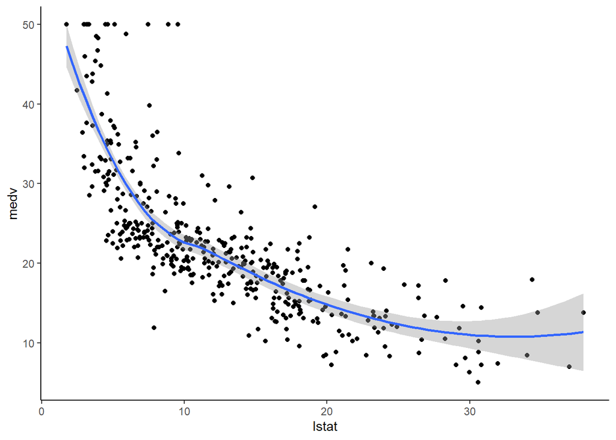

```r
ggplot(train.data, aes(lstat, medv) ) +
  geom_point() +
  stat_smooth()
```

The above scatter plot suggests a **non-linear relationship** between the two variables

```
We start by computing linear and non-linear regression models.
Next, we’ll compare the different models in order to choose the best one for our data.
```

####3. Linear regression

The standard linear regression model equation can be written as `medv = b0 + b1*lstat`.

Compute linear regression model:

```r
# 1. Build the model
( model <- lm(medv ~ lstat, data = train.data) )
```

```
##
## Call:
## lm(formula = medv ~ lstat, data = train.data)
##
## Coefficients:
## (Intercept)        lstat
##     34.6527      -0.9561
```

```r
summary(model)
```

```
##
## Call:
## lm(formula = medv ~ lstat, data = train.data)
##
## Residuals:
##     Min      1Q  Median      3Q     Max
## -15.218  -4.011  -1.123   2.025  24.459
##
## Coefficients:
##             Estimate Std. Error t value Pr(>|t|)
## (Intercept)  34.6527     0.6230   55.62   <2e-16 ***
## lstat        -0.9561     0.0428  -22.34   <2e-16 ***
## ---
## Signif. codes:  0 '***' 0.001 '**' 0.01 '*' 0.05 '.' 0.1 ' ' 1
##
## Residual standard error: 6.144 on 405 degrees of freedom
## Multiple R-squared:  0.5521, Adjusted R-squared:  0.551
## F-statistic: 499.2 on 1 and 405 DF,  p-value: < 2.2e-16
```

```r
# 2. Make predictions
( predictions <- model %>% predict(test.data) )
```

```
##         3         6         9        11        14        15        31        32
## 30.799509 29.671272  6.035668 15.099807 26.755067 24.842801 13.044121 22.184752
##        36        41        45        51        54        74        76        78
## 25.397358 32.759581 25.521655 21.792737 26.592524 27.443482 26.104896 24.833240
##        79        82        86        92       105       108       109       111
## 22.854045 27.749445 28.409177 26.812435 22.863606 21.180812 22.920974 22.222997
##       120       127       130       131       138       142       146       151
## 21.639756  8.588542 17.117247 22.605450 20.702746  1.752192  8.072231 21.171251
##       152       155       163       167       168       170       172       178
## 21.955280 20.195995 32.816949 31.115033 23.045271 23.829300 23.150446 28.638649
##       182       184       188       198       203       205       215       218
## 25.617269 29.221890 28.265757 26.420420 31.679151 31.899062  6.398998 25.387797
##       221       224       244       246       247       250       252       255
## 25.368674 27.386114 29.690395 17.002512 25.894547 28.380493 31.220207 28.370931
##       257       262       271       293       294       300       305       307
## 31.679151 27.711200 22.222997 30.158900 26.449104 30.120654 28.026723 28.466545
##       312       316       320       323       326       330       348       352
## 28.935050 23.657196 22.481153 27.290501 29.795569 27.634709 28.571719 29.403555
##       355       357       370       378       393       394       401       403
## 26.955855 17.824786 31.086349 14.344462 10.099232 20.148189  9.057047 15.233666
##       405       406       410       411       417       422       445       449
##  8.473806 12.680791 15.740416 24.986221  9.994058 19.641438 11.906323 17.318035
##       453       455       472       481       484       486       487       490
## 18.140310 16.763478 22.347294 24.383857 24.689820 24.536839 20.329854 11.734219
##       493       495       496
## 21.888350 21.658879 17.824786
```

```r
# 3. Model performance
data.frame(
  RMSE = RMSE(predictions, test.data$medv),
  R2 = R2(predictions, test.data$medv)
)
```

```
##       RMSE       R2
## 1 6.503817 0.513163
```

Visualize the data:

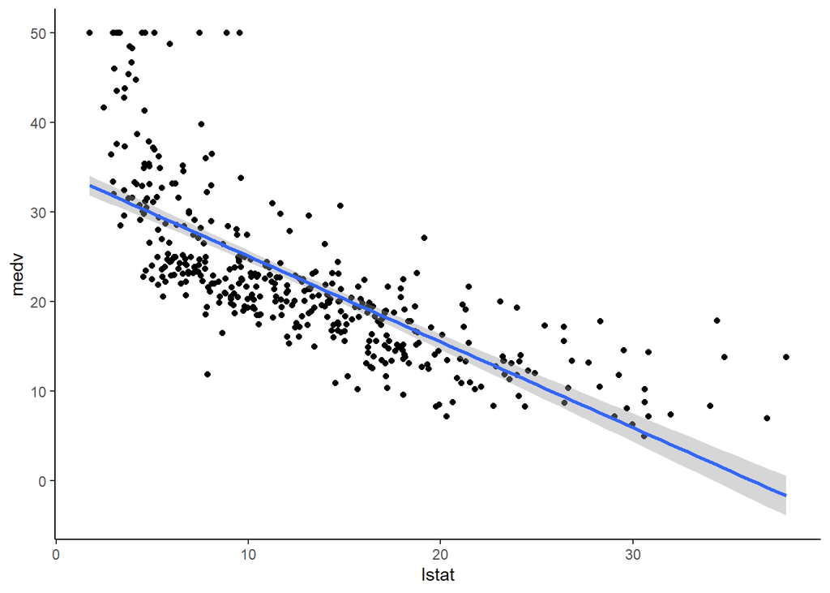

```r
ggplot(train.data, aes(lstat, medv) ) +
  geom_point() +
  stat_smooth(method = lm, formula = y ~ x)
```

####4. Polynomial regression

The polynomial regression adds polynomial or quadratic terms to the regression equation as follow:

- `medv=b0 + b1∗lstat + b2∗lstat2`

In R, to create a predictor **x^2** you should use the function **I{base}**, as follow: `I(x^2)`. This raise x to the power 2.

The polynomial regression can be computed in R as follow:

```r
lm(medv ~ lstat + I(lstat^2), data = train.data)
```

```
##
## Call:
## lm(formula = medv ~ lstat + I(lstat^2), data = train.data)
##
## Coefficients:
## (Intercept)        lstat   I(lstat^2)
##     42.5736      -2.2673       0.0412
```

An alternative simple solution is to use this:

```r
lm(medv ~ poly(lstat, 2, raw = TRUE), data = train.data)
```

```
##
## Call:
## lm(formula = medv ~ poly(lstat, 2, raw = TRUE), data = train.data)
##
## Coefficients:
##                 (Intercept)  poly(lstat, 2, raw = TRUE)1
##                     42.5736                      -2.2673
## poly(lstat, 2, raw = TRUE)2
##                      0.0412
```

The output contains two coefficients associated with lstat : one for the linear term (**lstat<sup>1**) and one for the quadratic term (**lstat</sup>2**).

The following example computes a **sixfth-order** polynomial fit:

```r
lm(medv ~ poly(lstat, 6, raw = TRUE), data = train.data) %>% summary()
```

```
##
## Call:
## lm(formula = medv ~ poly(lstat, 6, raw = TRUE), data = train.data)
##
## Residuals:
##      Min       1Q   Median       3Q      Max
## -13.1962  -3.1527  -0.7655   2.0404  26.7661
##
## Coefficients:
##                               Estimate Std. Error t value Pr(>|t|)
## (Intercept)                  7.788e+01  6.844e+00  11.379  < 2e-16 ***
## poly(lstat, 6, raw = TRUE)1 -1.767e+01  3.569e+00  -4.952 1.08e-06 ***
## poly(lstat, 6, raw = TRUE)2  2.417e+00  6.779e-01   3.566 0.000407 ***
## poly(lstat, 6, raw = TRUE)3 -1.761e-01  6.105e-02  -2.885 0.004121 **
## poly(lstat, 6, raw = TRUE)4  6.845e-03  2.799e-03   2.446 0.014883 *
## poly(lstat, 6, raw = TRUE)5 -1.343e-04  6.290e-05  -2.136 0.033323 *
## poly(lstat, 6, raw = TRUE)6  1.047e-06  5.481e-07   1.910 0.056910 .
## ---
## Signif. codes:  0 '***' 0.001 '**' 0.01 '*' 0.05 '.' 0.1 ' ' 1
##
## Residual standard error: 5.188 on 400 degrees of freedom
## Multiple R-squared:  0.6845, Adjusted R-squared:  0.6798
## F-statistic: 144.6 on 6 and 400 DF,  p-value: < 2.2e-16
```

From the output above, it can be seen that polynomial terms beyond the fith order are not significant.

So, just create a fith polynomial regression model as follow:

```r
# 1. Build the model
( model <- lm(medv ~ poly(lstat, 5, raw = TRUE), data = train.data) )
```

```
##
## Call:
## lm(formula = medv ~ poly(lstat, 5, raw = TRUE), data = train.data)
##
## Coefficients:
##                 (Intercept)  poly(lstat, 5, raw = TRUE)1
##                   6.765e+01                   -1.177e+01
## poly(lstat, 5, raw = TRUE)2  poly(lstat, 5, raw = TRUE)3
##                   1.220e+00                   -6.385e-02
## poly(lstat, 5, raw = TRUE)4  poly(lstat, 5, raw = TRUE)5
##                   1.577e-03                   -1.459e-05
```

```r
summary(model)
```

```
##
## Call:
## lm(formula = medv ~ poly(lstat, 5, raw = TRUE), data = train.data)
##
## Residuals:
##      Min       1Q   Median       3Q      Max
## -13.1519  -3.1235  -0.5927   2.0962  27.1286
##
## Coefficients:
##                               Estimate Std. Error t value Pr(>|t|)
## (Intercept)                  6.765e+01  4.273e+00  15.831  < 2e-16 ***
## poly(lstat, 5, raw = TRUE)1 -1.177e+01  1.786e+00  -6.588 1.40e-10 ***
## poly(lstat, 5, raw = TRUE)2  1.220e+00  2.580e-01   4.727 3.16e-06 ***
## poly(lstat, 5, raw = TRUE)3 -6.385e-02  1.644e-02  -3.884 0.000120 ***
## poly(lstat, 5, raw = TRUE)4  1.577e-03  4.714e-04   3.345 0.000901 ***
## poly(lstat, 5, raw = TRUE)5 -1.459e-05  4.954e-06  -2.945 0.003421 **
## ---
## Signif. codes:  0 '***' 0.001 '**' 0.01 '*' 0.05 '.' 0.1 ' ' 1
##
## Residual standard error: 5.205 on 401 degrees of freedom
## Multiple R-squared:  0.6816, Adjusted R-squared:  0.6777
## F-statistic: 171.7 on 5 and 401 DF,  p-value: < 2.2e-16
```

```r
# 2. Make predictions
( predictions <- model %>% predict(test.data) )
```

```
##        3        6        9       11       14       15       31       32
## 36.25964 31.52683 10.98130 14.57053 24.46163 22.15775 12.92118 20.10125
##       36       41       45       51       54       74       76       78
## 22.71496 48.66226 22.85021 19.83281 24.21677 25.63514 23.54555 22.14874
##       79       82       86       92      105      108      109      111
## 20.56661 26.23695 27.73305 24.55079 20.57337 19.41285 20.61408 20.12753
##      120      127      130      131      138      142      146      151
## 19.72815 10.84275 16.29523 20.39206 19.07990 12.17271 10.79233 19.40625
##      152      155      163      167      168      170      172      178
## 19.94399 18.71915 49.12384 37.86148 20.70288 21.28942 20.77874 28.32461
##      182      184      188      198      203      205      215      218
## 22.95714 30.01693 27.38287 23.96944 41.07512 42.45894 10.90664 22.70472
##      221      224      244      246      247      250      252      255
## 22.68432 25.52817 31.59542 16.19812 23.28245 27.66184 38.42562 27.63824
##      257      262      271      293      294      300      305      307
## 41.07512 26.15875 20.12753 33.39485 24.00984 33.23907 26.83083 27.87727
##      312      316      320      323      326      330      348      352
## 29.14921 21.15591 20.30565 25.35379 31.97926 26.00495 28.14799 30.60433
##      355      357      370      378      393      394      401      403
## 24.78018 16.88593 37.71030 13.93897 11.23408 18.68462 10.92539 14.68427
##      405      406      410      411      417      422      445      449
## 10.82788 12.65967 15.11768 22.29518 11.19528 18.31274 12.14580 16.46438
##      453      455      472      481      484      486      487      490
## 17.14384 15.99490 20.21310 21.74457 22.01575 21.87813 18.81536 12.04060
##      493      495      496
## 19.89820 19.74124 16.88593
```

```r
# 3. Model performance
data.frame(
  RMSE = RMSE(predictions, test.data$medv),
  R2 = R2(predictions, test.data$medv)
)
```

```
##       RMSE        R2
## 1 5.270374 0.6829474
```

Visualize the fith polynomial regression line as follow:

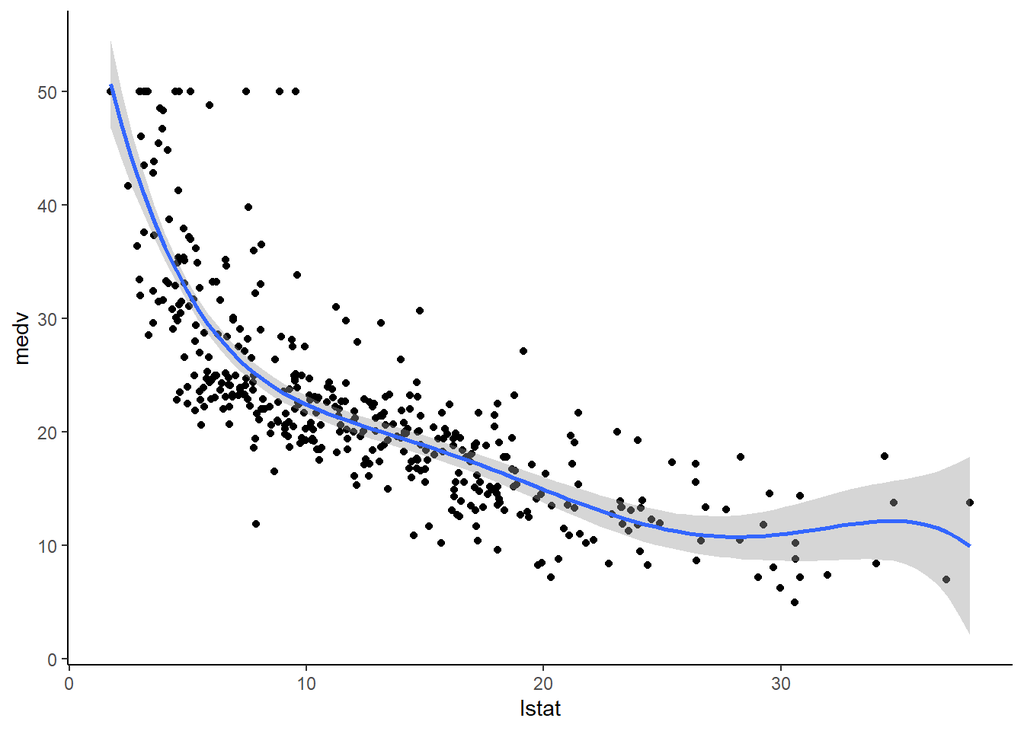

```r
ggplot(train.data, aes(lstat, medv) ) +
  geom_point() +
  stat_smooth(method = lm, formula = y ~ poly(x, 5, raw = TRUE))
```

###5. Log transformation

When you have a non-linear relationship, you can also try a logarithm transformation of the predictor variables:

```r
# 1. Build the model
( model <- lm(medv ~ log(lstat), data = train.data) )
```

```
##
## Call:
## lm(formula = medv ~ log(lstat), data = train.data)
##
## Coefficients:
## (Intercept)   log(lstat)
##       52.38       -12.57
```

```r
summary(model)
```

```
##
## Call:
## lm(formula = medv ~ log(lstat), data = train.data)
##
## Residuals:
##      Min       1Q   Median       3Q      Max
## -14.5381  -3.4903  -0.6408   2.0903  25.9510
##
## Coefficients:
##             Estimate Std. Error t value Pr(>|t|)
## (Intercept)   52.380      1.081   48.48   <2e-16 ***
## log(lstat)   -12.567      0.441  -28.50   <2e-16 ***
## ---
## Signif. codes:  0 '***' 0.001 '**' 0.01 '*' 0.05 '.' 0.1 ' ' 1
##
## Residual standard error: 5.295 on 405 degrees of freedom
## Multiple R-squared:  0.6672, Adjusted R-squared:  0.6664
## F-statistic: 812.1 on 1 and 405 DF,  p-value: < 2.2e-16
```

```r
# 2. Make predictions
( predictions <- model %>% predict(test.data) )
```

```
##         3         6         9        11        14        15        31        32
## 34.864855 31.637571  9.667542 14.453906 25.846300 23.121497 13.197656 20.108409
##        36        41        45        51        54        74        76        78
## 23.852762 43.795585 24.022672 19.719376 25.590290 26.992408 24.852140 23.109255
##        79        82        86        92       105       108       109       111
## 20.801780 27.537389 28.799683 25.937916 20.811968 19.135201 20.873269 20.147016
##       120       127       130       131       138       142       146       151
## 19.570767 10.841780 15.822393 20.539756 18.696989  7.914673 10.595278 19.126285
##       152       155       163       167       168       170       172       178
## 19.879224 18.248586 44.182282 35.938468 21.007122 21.885967 21.121507 29.270252
##       182       184       188       198       203       205       215       218
## 24.154954 30.552173 28.514281 25.324788 38.121420 39.086946  9.828113 23.839786
##       221       224       244       246       247       250       252       255
## 23.813876 26.892804 31.685905 15.740436 24.546638 28.742082 36.317737 28.722940
##       257       262       271       293       294       300       305       307
## 38.121420 27.467960 20.147016 32.932154 25.368650 32.825656 28.052560 28.915684
##       312       316       320       323       326       330       348       352
## 29.905376 21.687716 20.410764 26.728532 31.955113 27.330241 29.131173 30.979728
##       355       357       370       378       393       394       401       403
## 26.169923 16.339957 35.836987 13.977588 11.592109 18.207098 11.069721 14.540232
##       405       406       410       411       417       422       445       449
## 10.786583 12.988115 14.872520 23.306576 11.538395 17.775548 12.552793 15.967116
##       453       455       472       481       484       486       487       490
## 16.577819 15.571391 20.273315 22.546922 22.927038 22.735543 18.365486 12.458069
##       493       495       496
## 19.813158 19.589247 16.339957
```

```r
# 3. Model performance
data.frame(
  RMSE = RMSE(predictions, test.data$medv),
  R2 = R2(predictions, test.data$medv)
)
```

```
##       RMSE        R2
## 1 5.467124 0.6570091
```

Visualize the data:

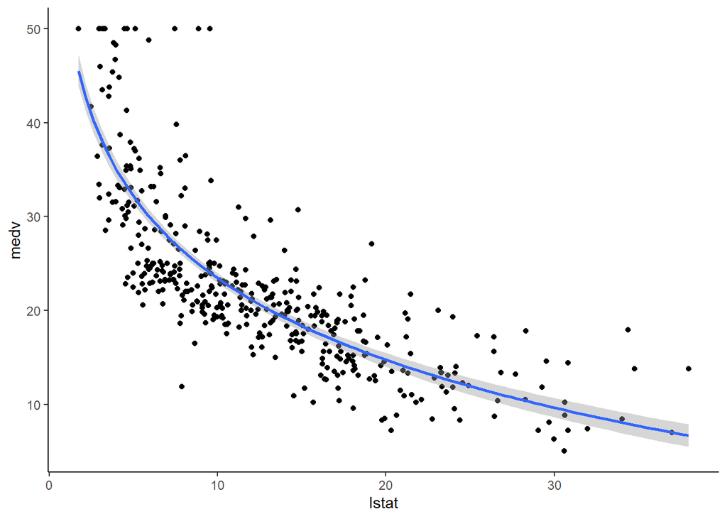

```r
ggplot(train.data, aes(lstat, medv) ) +
  geom_point() +
  stat_smooth(method = lm, formula = y ~ log(x))
```

###6. Spline regression

Polynomial regression only captures a certain amount of curvature in a nonlinear relationship. An alternative, and often superior, approach to modeling nonlinear relationships is to use splines (P. Bruce and Bruce 2017).

Splines provide a way to smoothly interpolate between fixed points, called knots. Polynomial regression is computed between knots. In other words, splines are series of polynomial segments strung together, joining at knots (P. Bruce and Bruce 2017).

The R package splines includes the function bs for creating a b-spline term in a regression model.

You need to specify two parameters:  
- the degree of the polynomial  
- the location of the knots

In our example, we’ll place the knots at the lower quartile, the median quartile, and the upper quartile:

```r
( knots <- quantile(train.data$lstat, p = c(0.25, 0.5, 0.75)) )
```

```
##    25%    50%    75%
##  6.965 11.410 17.025
```

We’ll create a model using a cubic spline (degree = 3):

```r
library(splines)

# 1. Build the model
knots <- quantile(train.data$lstat, p = c(0.25, 0.5, 0.75))
model <- lm (medv ~ bs(lstat, knots = knots), data = train.data)

# 2. Make predictions
predictions <- model %>% predict(test.data)

# 3. Model performance
data.frame(
  RMSE = RMSE(predictions, test.data$medv),
  R2 = R2(predictions, test.data$medv)
)
```

```
##       RMSE        R2
## 1 5.317372 0.6786367
```

```
Note that, the coefficients for a spline term are not interpretable.
```

Visualize the cubic spline as follow:

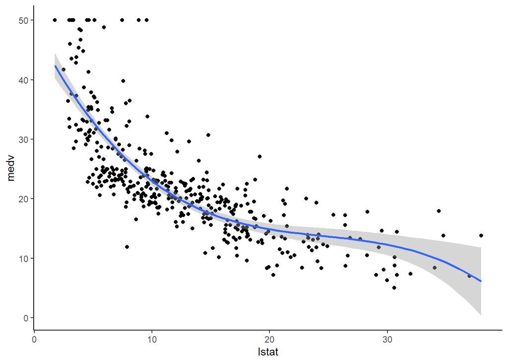

```r
ggplot(train.data, aes(lstat, medv) ) +
  geom_point() +
  stat_smooth(method = lm, formula = y ~ splines::bs(x, df = 3))
```

###7. Generalized additive models (GAM)

Once you have detected a non-linear relationship in your data, the polynomial terms may not be flexible enough to capture the relationship, and spline terms require specifying the knots.

Generalized additive models, or GAM, are a technique to automatically fit a spline regression. This can be done using the {mgcv} package:

```r
library(mgcv)

# 1. Build the model
model <- gam(medv ~ s(lstat), data = train.data)

# 2. Make predictions
predictions <- model %>% predict(test.data)

# 3. Model performance
data.frame(
  RMSE = RMSE(predictions, test.data$medv),
  R2 = R2(predictions, test.data$medv)
)
```

```
##       RMSE        R2
## 1 5.318856 0.6760512
```

The term s(lstat) tells the gam() function to find the “best” knots for a spline term.

Visualize the data:

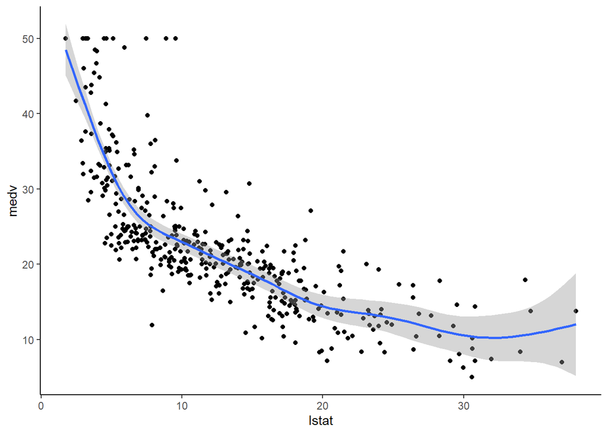

```r
ggplot(train.data, aes(lstat, medv) ) +
  geom_point() +
  stat_smooth(method = gam, formula = y ~ s(x))
```

###8. Comparing the models

From analyzing the **RMSE** and the **R2** metrics of the different models, it can be seen that the **polynomial** regression, the **spline** regression and the **generalized additive models** outperform the **linear** regression model and the **log transformation** approaches.